# FIFA2017

Hitesh Vedwal

9 November 2017

This is an exploratory analysis of the FIFA 2017 Player dataset, which can be found [here](https://www.kaggle.com/artimous/complete-fifa-2017-player-dataset-global).

In this script we’d be look at following things.

- 1.Import data
- 2.Age Density of FIFA Players
- 2.Feature Engineering
- 3.Overall Best Club team by players rating
- 4.Which continent player’s are best at particular Attribute.(Example: Stamina, Ball_Control)
- 5.Best players, and Which Attribute which player has to develop.
- 6.Radar chart for top 20 players
- 7.Dream 11 players

```r
# Importing Library
library(readr)
library(data.table)
library(sqldf)
library(dplyr)
library(radarchart)
library(tidyr)
library(dplyr)
library("knitr")
library(DT)
library(ggplot2)
```

## Import data

```r
FullData <- read_csv("C:/Users/vdwal/Desktop/mini project 5th sem/FIFA Dataset/FullData.csv")
setDT(FullData)
names(FullData)
```

```
##  [1] "Name"               "Nationality"        "National_Position"
##  [4] "National_Kit"       "Club"               "Club_Position"
##  [7] "Club_Kit"           "Club_Joining"       "Contract_Expiry"
## [10] "Rating"             "Height"             "Weight"
## [13] "Preffered_Foot"     "Birth_Date"         "Age"
## [16] "Preffered_Position" "Work_Rate"          "Weak_foot"
## [19] "Skill_Moves"        "Ball_Control"       "Dribbling"
## [22] "Marking"            "Sliding_Tackle"     "Standing_Tackle"
## [25] "Aggression"         "Reactions"          "Attacking_Position"
## [28] "Interceptions"      "Vision"             "Composure"
## [31] "Crossing"           "Short_Pass"         "Long_Pass"
## [34] "Acceleration"       "Speed"              "Stamina"
## [37] "Strength"           "Balance"            "Agility"
## [40] "Jumping"            "Heading"            "Shot_Power"
## [43] "Finishing"          "Long_Shots"         "Curve"
## [46] "Freekick_Accuracy"  "Penalties"          "Volleys"
## [49] "GK_Positioning"     "GK_Diving"          "GK_Kicking"
## [52] "GK_Handling"        "GK_Reflexes"
```

```r
dim(FullData)
```

```
## [1] 17588    53
```

```r
kable(head(FullData))
```

| Name | Nationality | National_Position | National_Kit | Club | Club_Position | Club_Kit | Club_Joining | Contract_Expiry | Rating | Height | Weight | Preffered_Foot | Birth_Date | Age | Preffered_Position | Work_Rate | Weak_foot | Skill_Moves | Ball_Control | Dribbling | Marking | Sliding_Tackle | Standing_Tackle | Aggression | Reactions | Attacking_Position | Interceptions | Vision | Composure | … |
| --- | --- | --- | --- | --- | --- | --- | --- | --- | --- | --- | --- | --- | --- | --- | --- | --- | --- | --- | --- | --- | --- | --- | --- | --- | --- | --- | --- | --- | --- | --- |
| Cristiano Ronaldo | Portugal | LS | 7 | Real Madrid | LW | 7 | 07/01/2009 | 2021 | 94 | 185 cm | 80 kg | Right | 02/05/1985 | 32 | LW/ST | High / Low | 4 | 5 | 93 | 92 | 22 | 23 | 31 | 63 | 96 | 94 | 29 | 85 | 86 | … |
| Lionel Messi | Argentina | RW | 10 | FC Barcelona | RW | 10 | 07/01/2004 | 2018 | 93 | 170 cm | 72 kg | Left | 06/24/1987 | 29 | RW | Medium / Medium | 4 | 4 | 95 | 97 | 13 | 26 | 28 | 48 | 95 | 93 | 22 | 90 | 94 | … |
| Neymar | Brazil | LW | 10 | FC Barcelona | LW | 11 | 07/01/2013 | 2021 | 92 | 174 cm | 68 kg | Right | 02/05/1992 | 25 | LW | High / Medium | 5 | 5 | 95 | 96 | 21 | 33 | 24 | 56 | 88 | 90 | 36 | 80 | 80 | … |
| Luis Suárez | Uruguay | LS | 9 | FC Barcelona | ST | 9 | 07/11/2014 | 2021 | 92 | 182 cm | 85 kg | Right | 01/24/1987 | 30 | ST | High / Medium | 4 | 4 | 91 | 86 | 30 | 38 | 45 | 78 | 93 | 92 | 41 | 84 | 83 | … |
| Manuel Neuer | Germany | GK | 1 | FC Bayern | GK | 1 | 07/01/2011 | 2021 | 92 | 193 cm | 92 kg | Right | 03/27/1986 | 31 | GK | Medium / Medium | 4 | 1 | 48 | 30 | 10 | 11 | 10 | 29 | 85 | 12 | 30 | 70 | 70 | … |
| De Gea | Spain | GK | 1 | Manchester Utd | GK | 1 | 07/01/2011 | 2019 | 90 | 193 cm | 82 kg | Right | 11/07/1990 | 26 | GK | Medium / Medium | 3 | 1 | 31 | 13 | 13 | 13 | 21 | 38 | 88 | 12 | 30 | 68 | 60 | … |

```r
# Unique values per column
#lapply(FullData, function(x) length(unique(x)))
```

## Age Density of FIFA Players

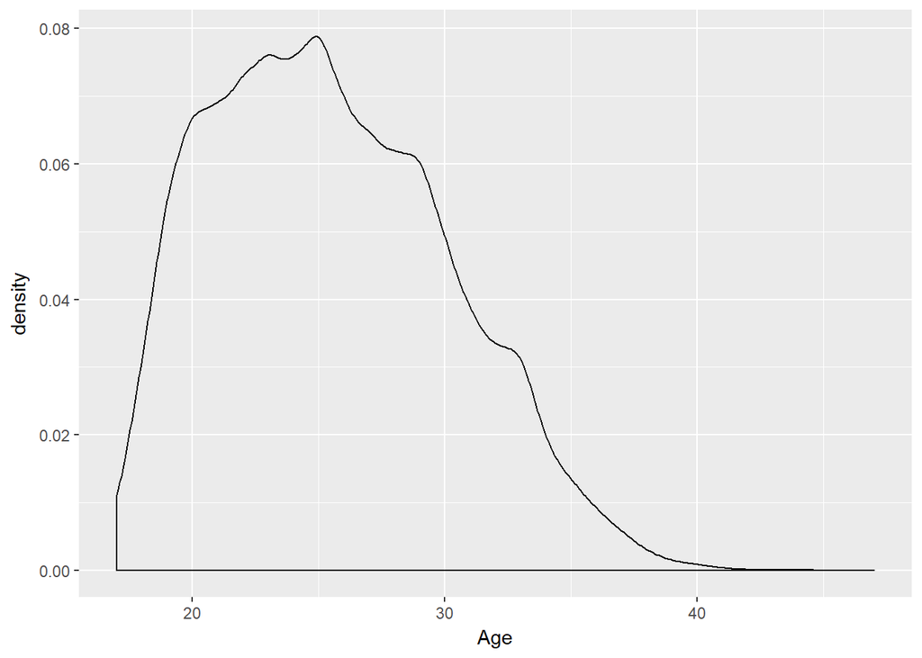

```r
ggplot(FullData, aes(Age, fill = Age)) +
geom_density(position = "stack")
```

## Overall Best Club team by players rating

```r
#Groping players by club and appling average on players rating
TeamDF<-arrange(FullData[, list(Avg=mean(Rating)), by= "Club" ], desc(Avg) )

kable(head(TeamDF, 10))
```

| Club | Avg |
| --- | --- |
| Free agent | 81.00000 |
| Juventus | 79.78571 |
| FC Bayern | 79.11538 |
| Real Madrid | 78.75758 |
| FC Barcelona | 78.09091 |
| Napoli | 77.76923 |
| Roma | 77.76000 |
| Sevilla FC | 76.96429 |
| PSG | 76.70968 |
| Atlético Madrid | 76.54839 |

```r
kable(tail(TeamDF, 10))
```

|  | Club | Avg |
| --- | --- | --- |
| 625 | Shamrock Rovers | 56.64000 |
| 626 | Crewe Alexandra | 56.03704 |
| 627 | Bray Wanderers | 56.00000 |
| 628 | Sligo Rovers | 55.73913 |
| 629 | Galway United | 54.90476 |
| 630 | Bohemian FC | 54.79167 |
| 631 | Finn Harps | 54.64000 |
| 632 | Derry City | 54.54167 |
| 633 | Longford Town | 52.20000 |
| 634 | Wexford Youths | 51.86364 |

**Ohh What i see, Free Agent! which is not a team. Player who are not in club are under Free agent**

Creating new DF removing Free Agent players

```r
FullData_RFA<- filter(FullData, !Club %in% c('Free agent'))

setDT(FullData_RFA)#changing class to data.table

TeamDF_RFA<-arrange(FullData_RFA[, list(Avg=mean(Rating)), by= "Club" ], desc(Avg) )

kable(head(TeamDF_RFA, 10)) # Top 10
```

| Club | Avg |
| --- | --- |
| Juventus | 79.78571 |
| FC Bayern | 79.11538 |
| Real Madrid | 78.75758 |
| FC Barcelona | 78.09091 |
| Napoli | 77.76923 |
| Roma | 77.76000 |
| Sevilla FC | 76.96429 |
| PSG | 76.70968 |
| Atlético Madrid | 76.54839 |
| Arsenal | 76.33333 |

```r
kable(tail(TeamDF_RFA, 10)) # Bottom 10
```

|  | Club | Avg |
| --- | --- | --- |
| 624 | Shamrock Rovers | 56.64000 |
| 625 | Crewe Alexandra | 56.03704 |
| 626 | Bray Wanderers | 56.00000 |
| 627 | Sligo Rovers | 55.73913 |
| 628 | Galway United | 54.90476 |
| 629 | Bohemian FC | 54.79167 |
| 630 | Finn Harps | 54.64000 |
| 631 | Derry City | 54.54167 |
| 632 | Longford Town | 52.20000 |
| 633 | Wexford Youths | 51.86364 |

## Which continent player’s are best at which particular Attribute.

#### Approach(Player Attribute - stamina )

#### 1.Selecting top 100 stamina players

#### 2.Then group by Nationality

```r
stamina_desc100 <- head(arrange(FullData, desc(Stamina)), n=100)
```

```r
stamina_list <- stamina_desc100 %>% group_by(Nationality)  %>% summarise(n = n()) %>% arrange(desc(n))

datatable(stamina_list, style="bootstrap", class="table-condensed", options = list(dom = 'tp',scrollX = TRUE))
```

|  | Nationality | n |
| --- | --- | --- |
| 1 | France | 10 |
| 2 | Italy | 9 |
| 3 | Brazil | 7 |
| 4 | England | 6 |
| 5 | Spain | 6 |
| 6 | Austria | 5 |
| 7 | Netherlands | 5 |
| 8 | Sweden | 5 |
| 9 | Argentina | 4 |
| 10 | Colombia | 3 |

[output cut: 26 more lines]

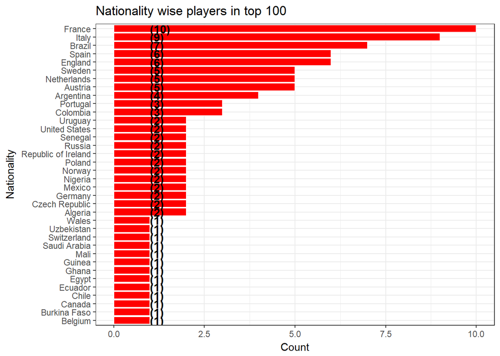

**Lets lookin at Continent level, Made a list of Continent_contries.**

```r
africa<-c('Algeria','Angola','Benin','Botswana','Burkina','Burundi','Cameroon','Cape Verde','Central African Republic','Chad','Comoros','Congo','Congo Democratic Republic of','Djibouti','Egypt','Equatorial Guinea','Eritrea','Ethiopia','Gabon','Gambia','Ghana','Guinea','Guinea-Bissau','Ivory Coast','Kenya','Lesotho','Liberia','Libya','Madagascar','Malawi','Mali','Mauritania','Mauritius','Morocco','Mozambique','Namibia','Niger','Nigeria','Rwanda','Sao Tome and Principe','Senegal','Seychelles','Sierra Leone','Somalia','South Africa','South Sudan','Sudan','Swaziland','Tanzania','Togo','Tunisia','Uganda','Zambia','Zimbabwe','Burkina Faso')
asia<-c('Afghanistan','Bahrain','Bangladesh','Bhutan','Brunei','Burma (Myanmar)','Cambodia','China','East Timor','India','Indonesia','Iran','Iraq','Israel','Japan','Jordan','Kazakhstan','North Korea','South Korea','Kuwait','Kyrgyzstan','Laos','Lebanon','Malaysia','Maldives','Mongolia','Nepal','Oman','Pakistan','Philippines','Qatar','Russian Federation','Saudi Arabia','Singapore','Sri Lanka','Syria','Tajikistan','Thailand','Turkey','Turkmenistan','United Arab Emirates','Uzbekistan','Vietnam','Yemen','Russia')
europe<-c('Albania','Andorra','Armenia','Austria','Azerbaijan','Belarus','Belgium','Bosnia and Herzegovina','Bulgaria','Croatia','Cyprus','Czech Republic','Denmark','Estonia','Finland','France','Georgia','Germany','Greece','Hungary','Iceland','Ireland','Italy','Latvia','Liechtenstein','Lithuania','Luxembourg','Macedonia','Malta','Moldova','Monaco','Montenegro','Netherlands','Norway','Poland','Portugal','Romania','San Marino','Serbi','Slovakia','Slovenia','Spain','Sweden','Switzerland','Ukraine','England','Vatican City','Republic of Ireland','Wales')
north_america<-c('Antigua and Barbuda','Bahamas','Barbados','Belize','Canada','Costa Rica','Cuba','Dominica','Dominican Republic','El Salvador','Grenada','Guatemala','Haiti','Honduras','Jamaica','Mexico','Nicaragua','Panama','Saint Kitts and Nevis','Saint Lucia','Saint Vincent and the Grenadines','Trinidad and Tobago','United States')
oceania<-c('Australia','Fiji','Kiribati','Marshall Islands','Micronesia','Nauru','New Zealand','Palau','Papua New Guinea','Samoa','Solomon Islands','Tonga','Tuvalu','Vanuatu')
south_america<-c('Argentina','Bolivia','Brazil','Chile','Colombia','Ecuador','Guyana','Paraguay','Peru','Suriname','Uruguay','Venezuela')
```

**chainging country by continent name**

```r
stamina_list$Nationality[stamina_list$Nationality %in% africa] <- "africa"
stamina_list$Nationality[stamina_list$Nationality %in% asia] <- "asia"
stamina_list$Nationality[stamina_list$Nationality %in% europe] <- "europe"
stamina_list$Nationality[stamina_list$Nationality %in% north_america] <- "north_america"
stamina_list$Nationality[stamina_list$Nationality %in% oceania]<-"oceania"
stamina_list$Nationality[stamina_list$Nationality %in% south_america]<-"south_america"

unique(stamina_list$Nationality) # Check for nationality values
```

```
## [1] "europe"        "south_america" "africa"        "north_america"
## [5] "asia"
```

```r
stamina_list <- stamina_list %>% group_by(Nationality) %>% summarise(n = n()) %>% arrange(desc(n))


datatable(stamina_list, style="bootstrap", class="table-condensed", options = list(dom = 'tp',scrollX = TRUE))
```

|  | Nationality | n |
| --- | --- | --- |
| 1 | europe | 16 |
| 2 | africa | 8 |
| 3 | south_america | 6 |
| 4 | asia | 3 |
| 5 | north_america | 3 |

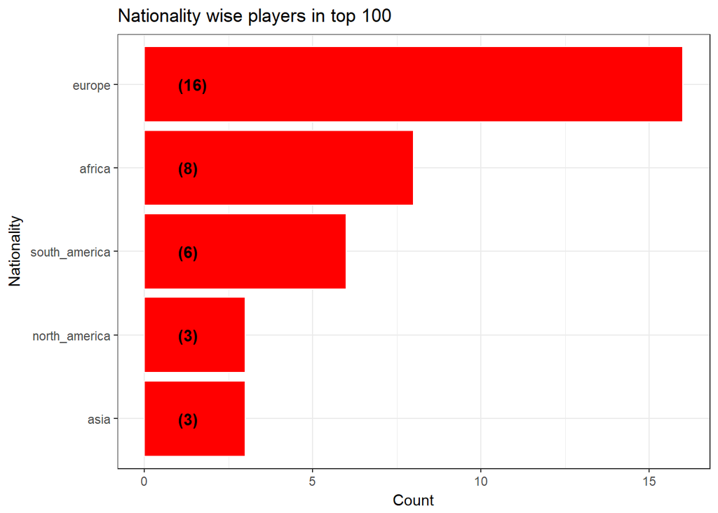

## Best players, and Which Attribute which player has to develop/improve,,

Most intresting part which I love the most, learning and imporving !!

#### For Best players Approach

#### 1.Then group by Preffered_Position

#### 2.Considering players skill below 95 percentile has to be improved, makring player Attributes development as “Yes”.

```r
# Most intresting  part which I love,learning and imporving !!
# Making a subset with selective attributes. For clarity and time being i am including selective attributes.User can do with all.

FullData_Subset <- subset(FullData, select = c("Name" ,"Nationality", "Rating", "Preffered_Position", "Ball_Control", "Dribbling", "Marking","Sliding_Tackle", "Standing_Tackle", "Aggression", "Reactions", "Attacking_Position", "Crossing", "Acceleration", "Balance", "GK_Positioning","GK_Diving","GK_Kicking","GK_Reflexes","Penalties","Volleys" ))

FullData_Subset$Preffered_Position <- gsub("/*", "", FullData_Subset$Preffered_Position )

unique(FullData_Subset$Preffered_Position)
```

```
##   [1] "LWST"     "RW"       "LW"       "ST"       "GK"       "CB"
##   [7] "LWLM"     "CMCDM"    "CAMLW"    "CMCAM"    "STLW"     "CAMRMLM"
##  [13] "LMCAM"    "STRM"     "RBCM"     "CM"       "CAMRM"    "CAMLM"
##  [19] "RMRW"     "STCAM"    "LBCM"     "RMCAM"    "CFCAMST"  "CDMCM"
##  [25] "CMCDMLM"  "LB"       "LWCAM"    "RWCAM"    "LMLW"     "CAMCDM"
##  [31] "CAMCM"    "CBCDM"    "RB"       "CMRM"     "LBLM"     "LM"
##  [37] "CBRB"     "CAM"      "CMLW"     "CDM"      "RM"       "CBLB"
##  [43] "LMRM"     "STRW"     "CMRW"     "RWLW"     "CMLM"     "CFST"
##  [49] "STLM"     "RBCB"     "LMCMCAM"  "CAMCF"    "CAMST"    "LWCAMLM"
##  [55] "RBRM"     "RMLM"     "CAMLMLW"  "LMST"     "RWRM"     "CAMSTCF"
##  [61] "CDMCB"    "LBCB"     "RBRWB"    "RWST"     "LWCF"     "CDMRM"
##  [67] "RMST"     "LBCDM"    "LMRW"     "RMLW"     "RWCMLW"   "RBRW"
##  [73] "LBRB"     "LBLWB"    "CAMRW"    "LWRW"     "CMRBCDM"  "CDMRB"
##  [79] "CMCAMLM"  "CFRM"     "RBLB"     "CFCAM"    "LMCM"     "CFLW"
##  [85] "RMCAMST"  "STRMRW"   "CAMCMLM"  "RBRWRWB"  "RMRB"     "CMCB"
```

[output cut: 34 more lines]

## Feature Engineering

Chaning postions into - Forward , Midfielder, Defender , Goalkeeper

Looking into Preffered_Position i found

For Forward player preffered position ends with W

For Goalkeeper preffered position is GK

preffered position - STCF,ST,CF,CFST are Forward player

```r
FullData_Subset$Preffered_Position <- gsub("/*.^", "", FullData_Subset$Preffered_Position )
FullData_Subset$Preffered_Position <- gsub("^.*W", "Forward", FullData_Subset$Preffered_Position )
FullData_Subset$Preffered_Position <- gsub("Forward*.^", "Forward", FullData_Subset$Preffered_Position )
FullData_Subset$Preffered_Position <- gsub("GK", "Goalkeeper", FullData_Subset$Preffered_Position )
FullData_Subset$Preffered_Position <- gsub("^.*B", "Defender", FullData_Subset$Preffered_Position )
FullData_Subset$Preffered_Position <- gsub("Defender*.^", "Defender", FullData_Subset$Preffered_Position )
FullData_Subset$Preffered_Position <- gsub("^.*M", "Midfielder", FullData_Subset$Preffered_Position )
FullData_Subset$Preffered_Position <- gsub("Midfielder*.^", "Midfielder", FullData_Subset$Preffered_Position)
FullData_Subset$Preffered_Position <- gsub("STCF", "Forward", FullData_Subset$Preffered_Position )
FullData_Subset$Preffered_Position <- gsub("ST", "Forward", FullData_Subset$Preffered_Position )
FullData_Subset$Preffered_Position <- gsub("CF", "Forward", FullData_Subset$Preffered_Position )
FullData_Subset$Preffered_Position <- gsub("CFST", "Forward", FullData_Subset$Preffered_Position )

unique(FullData_Subset$Preffered_Position)
```

```
## [1] "ForwardForward"           "Forward"
## [3] "Goalkeeper"               "Defender"
## [5] "Midfielder"               "MidfielderForward"
## [7] "DefenderForward"          "MidfielderForwardForward"
```

```r
#Run it twice_thrice any number of times, if positions are not converted into  - Forward , Midfielder, Defender , Goalkeeper
```

```r
unique(FullData_Subset$Preffered_Position)
```

```
## [1] "ForwardForward"           "Forward"
## [3] "Goalkeeper"               "Defender"
## [5] "Midfielder"               "MidfielderForward"
## [7] "DefenderForward"          "MidfielderForwardForward"
```

```r
datatable(FullData_Subset, style="bootstrap", class="table-condensed", options = list(dom = 'tp',scrollX = TRUE))
```

|  | Name | Nationality | Rating | Preffered_Position | Ball_Control | Dribbling | Marking | Sliding_Tackle | Standing_Tackle | Aggression | Reactions | Attacking_Position | Crossing | Acceleration | Balance | GK_Positioning | GK_Diving | GK_Kicking | GK_Reflexes | Penalties | Volleys |
| --- | --- | --- | --- | --- | --- | --- | --- | --- | --- | --- | --- | --- | --- | --- | --- | --- | --- | --- | --- | --- | --- |
| 1 | Cristiano Ronaldo | Portugal | 94 | ForwardForward | 93 | 92 | 22 | 23 | 31 | 63 | 96 | 94 | 84 | 91 | 63 | 14 | 7 | 15 | 11 | 85 | 88 |
| 2 | Lionel Messi | Argentina | 93 | Forward | 95 | 97 | 13 | 26 | 28 | 48 | 95 | 93 | 77 | 92 | 95 | 14 | 6 | 15 | 8 | 74 | 85 |
| 3 | Neymar | Brazil | 92 | Forward | 95 | 96 | 21 | 33 | 24 | 56 | 88 | 90 | 75 | 93 | 82 | 15 | 9 | 15 | 11 | 81 | 83 |
| 4 | Luis Suárez | Uruguay | 92 | Forward | 91 | 86 | 30 | 38 | 45 | 78 | 93 | 92 | 77 | 88 | 60 | 33 | 27 | 31 | 37 | 85 | 88 |
| 5 | Manuel Neuer | Germany | 92 | Goalkeeper | 48 | 30 | 10 | 11 | 10 | 29 | 85 | 12 | 15 | 58 | 35 | 91 | 89 | 95 | 89 | 47 | 11 |
| 6 | De Gea | Spain | 90 | Goalkeeper | 31 | 13 | 13 | 13 | 21 | 38 | 88 | 12 | 17 | 56 | 43 | 86 | 88 | 87 | 90 | 40 | 13 |
| 7 | Robert Lewandowski | Poland | 90 | Forward | 87 | 85 | 25 | 19 | 42 | 80 | 88 | 89 | 62 | 79 | 79 | 8 | 15 | 12 | 10 | 81 | 86 |
| 8 | Gareth Bale | Wales | 90 | Forward | 88 | 89 | 51 | 52 | 55 | 65 | 87 | 86 | 87 | 93 | 65 | 5 | 15 | 11 | 6 | 76 | 76 |
| 9 | Zlatan Ibrahimović | Sweden | 90 | Forward | 90 | 87 | 15 | 27 | 41 | 84 | 85 | 86 | 76 | 69 | 41 | 9 | 13 | 10 | 12 | 91 | 93 |
| 10 | Thibaut Courtois | Belgium | 89 | Goalkeeper | 23 | 13 | 11 | 16 | 18 | 23 | 81 | 13 | 14 | 46 | 45 | 86 | 84 | 69 | 89 | 27 | 12 |

[output cut: 17578 more lines]

# Best player at positions - Forward , Midfielder, Defender , Goalkeeper

```r
sqldf("Select name ,Nationality,max(Rating) as max, Preffered_Position from FullData_Subset group by Preffered_Position ")
```

```
##                Name Nationality max       Preffered_Position
## 1    Jérôme Boateng     Germany  89                 Defender
## 2             Túlio       Japan  68          DefenderForward
## 3      Lionel Messi   Argentina  93                  Forward
## 4 Cristiano Ronaldo    Portugal  94           ForwardForward
## 5      Manuel Neuer     Germany  92               Goalkeeper
## 6       Eden Hazard     Belgium  89               Midfielder
## 7     Thomas Müller     Germany  86        MidfielderForward
## 8    Lukas Thürauer     Austria  65 MidfielderForwardForward
```

Creating seperate data frames for Forward , Midfielder, Defender , Goalkeeper players

```r
ForwardDF<- FullData_Subset%>% filter(FullData_Subset$Preffered_Position =="Forward")
MidfielderDF<- FullData_Subset%>% filter(FullData_Subset$Preffered_Position =="Midfielder")
DefenderDF<- FullData_Subset%>% filter(FullData_Subset$Preffered_Position =="Defender")
GoalkeeperDF<- FullData_Subset%>% filter(FullData_Subset$Preffered_Position =="Goalkeeper")
dim(GoalkeeperDF)
```

```
## [1] 2003   21
```

**Picking up Forward players data frame, Which Attribute which player has to develop.!**

Considering players skill below 95 percentile has to be improved, makring player Attributes development as “Yes”

Time being am selecting few Attribute.

|  | ForwardDF$Name | Ball_Control | Dribbling | Marking | Sliding_Tackle | Standing_Tackle | Aggression | Reactions | Attacking_Position | Crossing | Acceleration | Balance |
| --- | --- | --- | --- | --- | --- | --- | --- | --- | --- | --- | --- | --- |
| 1 | Lionel Messi | No | No | Yes | Yes | Yes | Yes | No | No | No | No | No |
| 2 | Neymar | No | No | Yes | Yes | Yes | Yes | No | No | No | No | Yes |
| 3 | Luis Suárez | No | No | Yes | Yes | Yes | No | No | No | No | No | Yes |
| 4 | Robert Lewandowski | No | No | Yes | Yes | Yes | No | No | No | Yes | Yes | Yes |
| 5 | Gareth Bale | No | No | No | No | No | Yes | No | No | No | No | Yes |
| 6 | Zlatan Ibrahimović | No | No | Yes | Yes | Yes | No | No | No | No | Yes | Yes |
| 7 | Mesut Özil | No | No | Yes | Yes | Yes | Yes | No | No | No | Yes | Yes |
| 8 | Gonzalo Higuaín | No | No | Yes | Yes | Yes | Yes | No | No | Yes | Yes | Yes |
| 9 | Sergio Agüero | No | No | Yes | Yes | Yes | Yes | No | No | Yes | No | No |
| 10 | Antoine Griezmann | No | No | Yes | Yes | Yes | Yes | No | No | No | Yes | Yes |

[output cut: 2760 more lines]

## Which Attribute which player has to develop.! - For Mid Fielder

|  | MidfielderDF$Name | Dribbling | Marking | Sliding_Tackle | Standing_Tackle | Reactions | Crossing | Balance |
| --- | --- | --- | --- | --- | --- | --- | --- | --- |
| 1 | Eden Hazard | No | Yes | Yes | Yes | No | No | No |
| 2 | Luka Modrić | No | Yes | No | No | No | No | No |
| 3 | Paul Pogba | No | Yes | No | No | No | No | Yes |
| 4 | Kevin De Bruyne | No | Yes | Yes | Yes | No | No | Yes |
| 5 | Marco Reus | No | Yes | Yes | Yes | No | No | Yes |
| 6 | Alexis Sánchez | No | Yes | Yes | Yes | No | No | No |
| 7 | Toni Kroos | Yes | Yes | Yes | No | No | No | Yes |
| 8 | Philipp Lahm | No | No | No | No | No | No | No |
| 9 | Iniesta | No | Yes | Yes | Yes | No | No | Yes |
| 10 | James Rodríguez | No | Yes | Yes | Yes | No | No | Yes |

[output cut: 6935 more lines]

## Which Attribute which player has to develop.! - For Defender

|  | DefenderDF$Name | Ball_Control | Dribbling | Sliding_Tackle | Aggression | Crossing | Balance |
| --- | --- | --- | --- | --- | --- | --- | --- |
| 1 | Jérôme Boateng | Yes | Yes | No | No | Yes | Yes |
| 2 | Thiago Silva | No | Yes | No | Yes | Yes | Yes |
| 3 | Sergio Ramos | No | Yes | No | No | Yes | Yes |
| 4 | Diego Godín | No | Yes | No | No | Yes | Yes |
| 5 | Mats Hummels | No | Yes | No | Yes | Yes | Yes |
| 6 | Giorgio Chiellini | Yes | Yes | No | No | Yes | Yes |
| 7 | Pepe | Yes | Yes | No | No | Yes | Yes |
| 8 | Leonardo Bonucci | No | Yes | No | No | Yes | Yes |
| 9 | Piqué | No | Yes | No | Yes | Yes | Yes |
| 10 | Jordi Alba | No | No | No | Yes | No | No |

[output cut: 5370 more lines]

##Which Attribute which player has to develop.! - For Goalkeeper

|  | GoalkeeperDF$Name | GK_Positioning | GK_Diving | GK_Kicking | Penalties | Volleys |
| --- | --- | --- | --- | --- | --- | --- |
| 1 | Manuel Neuer | No | No | No | No | Yes |
| 2 | De Gea | No | No | No | No | Yes |
| 3 | Thibaut Courtois | No | No | Yes | Yes | Yes |
| 4 | Hugo Lloris | No | No | Yes | No | Yes |
| 5 | Petr Čech | No | No | No | Yes | Yes |
| 6 | Gianluigi Buffon | No | No | Yes | Yes | Yes |
| 7 | Jan Oblak | No | No | No | Yes | Yes |
| 8 | Samir Handanovič | No | No | Yes | Yes | Yes |
| 9 | Bernd Leno | No | No | No | Yes | Yes |
| 10 | Keylor Navas | No | No | Yes | Yes | Yes |

[output cut: 1993 more lines]

## Radar chart for top 20 players

[interactive chart not shown]

## Soccer fans, Place your 11 players on ground- How do you want to play **offence or defence**

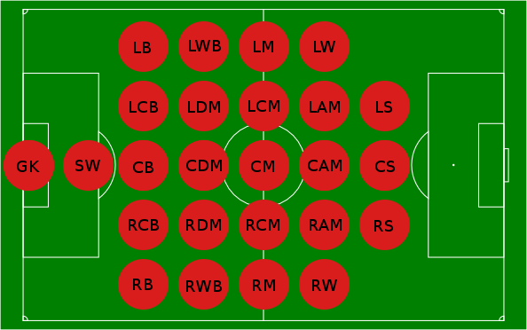

```r
#Considering fist value of Preffered_Position as default

FullData$position <- substr(FullData$Preffered_Position, start = 1, stop = 2)

#With the changes i have to revert back CA to CAM and CD to CDM

FullData$position[FullData$position == 'CA'] <- "CAM"
FullData$position[FullData$position == 'CD'] <- "CDM"

#Check unique position values

unique(FullData$position)
```

```
##  [1] "LW"  "RW"  "ST"  "GK"  "CB"  "CM"  "CAM" "LM"  "RB"  "RM"  "LB"
## [12] "CF"  "CDM"
```

```r
# list of players with highest ratinh among very positons,
```